# Classification: Loan Default Prediction

### Project Solution Notebook by Shweta Chandole

- Project Details
  - Data Description
  - Context and Objectives
  - Hypothesis Generation
- Understanding the data
  - Import Libraries
  - Read and explore dataset
  - Summary Statistics
- Data Pre-processing and Feature Engineering
  - Introducing feature: STATUS
  - Deleting rows with high missing features
  - Updating features: REASON and JOB
  - Updating features: DEROG, DELINQ and NINQ
  - Treating outliers
  - Data imputation - Replacing missing values
- Exploratory Data Analysis
  - Univariate Analysis
  - Hypothesis Verification
  - Bivariate Analysis
  - Multivariate Analysis
- Design Approach
- Model Evalution Criteria
- Data Preparation for Logistic Regression model
- Checking for Multicollinearity
- Logistic Regression
  - Logistic Regression model - baseline
  - Precision-Recall curve
  - Resampling of imbalanced data
  - Logistic Regression model - tuned
- Data preparation for Tree based models
- Decision Tree
  - DT Hyperparameter Tuning using GridSearchCV
  - Decision Tree model - tuned
  - Feature Importances for tuned Decision Tree model
  - Plot tuned Decision Tree
- Random Forest
  - RF Hyperparameter Tuning using GridSearchCV
  - Random Forest - tuned
  - Feature Importances for tuned Random Forest model
- Model performances Comparison
- Conclusion

## Project Details

### Data Description:

The Home Equity dataset (HMEQ) contains baseline and loan performance information for 5,960 recent home equity loans. The target (BAD) is a binary variable that indicates whether an applicant has ultimately defaulted or has been severely delinquent. This adverse outcome occurred in 1,189 cases (20 percent). 12 input variables were registered for each applicant.

- **BAD:** 1 = Client defaulted on loan, 0 = loan repaid
- **LOAN:** Amount of loan approved.
- **MORTDUE:** Amount due on the existing mortgage.
- **VALUE:** Current value of the property used as guarantee for loan.
- **REASON:** Reason for the loan request. (HomeImp = home improvement, DebtCon= debt consolidation which means taking out a new loan to pay off other liabilities and consumer debts)
- **JOB:** The type of job that loan applicant has such as manager, self, etc.
- **YOJ:** Years at present job.
- **DEROG:** Number of major derogatory reports (which indicates a serious delinquency or late payments).
- **DELINQ:** Number of delinquent credit lines (a line of credit becomes delinquent when a borrower does not make the minimum required payments 30 to 60 days past the day on which the payments were due).
- **CLAGE:** Age of the oldest credit line in months.
- **NINQ:** Number of recent credit inquiries.
- **CLNO:** Number of existing credit lines.
- **DEBTINC:** Debt-to-income ratio (For each applicant, all monthly debt payments divided by gross monthly income. This number is one way lenders measure borrower's ability to manage the monthly payments for the applied loan)

### Context:

- Consumer loans form a major proportion of revenue for retail banks.
- Home equity loans are a type of consumer loans based on the guarantee of existing home value of a loan applicant.
- The historic data presented in this problem is based on a manual approval process.
- As per the given data, there is a 2 in 10 chance of a borrower defaulting on the loan.
- Since the manual approval is based on various aspects of applicant's financial status in recent past, it is a high-risk process, with greater loss related to incorrect approvals.

### Objectives:

- To build a predictive machine learning model that classifies the loan applicant as most likely to be a defaulter or a non-deafulter, with increased accuracy as compared to the manual process.
- To maximize true positives rate for class 1 (defaulters) in order to avoid loss by inaccurate approvals (Highest Class 1 Recall score is most important)
- To check for removal of errors and bias towards any one of the two classes of target variable (thus weighted avergae F1 score is important)
- To minimize rejection of non-defaulters, in order to reduce loss by incorrect denials (class 0 Precision is also important)
- To have accuracy greater than 80%, since about 20% of applications are defaulters with current approval process
- To identify important independent features that help in classification of loan applicants as defaulters or non-defaulters based on the predictive model.

### Hypothesis generation:

Initial speculations about how each of the independent variables may be affecting the target variable (BAD) are:

These hypotheses will be verified in later steps.

Back to top

## Understanding the data:

Let us begin by importing the necessary libraries, dataset and look at its basic characteristics.

### Import the necessary libraries

```python
# import libraries for data manipulation
import numpy as np
import pandas as pd

# import libraries for data visualization
import matplotlib.pyplot as plt
import seaborn as sns

sns.set_theme()

# import library for preparing data
import sklearn
from sklearn.impute import SimpleImputer
from sklearn.preprocessing import PowerTransformer
import statsmodels.api as sm
from imblearn.over_sampling import SMOTE

# import libraries for building classifier models
from sklearn.model_selection import train_test_split
from sklearn.model_selection import GridSearchCV
from sklearn.linear_model import LogisticRegression
from sklearn import tree
from sklearn.tree import DecisionTreeClassifier
from sklearn.ensemble import BaggingClassifier
from sklearn.ensemble import RandomForestClassifier

from statsmodels.graphics.gofplots import ProbPlot

# import libraries for performance metrics
from sklearn import metrics
from sklearn.metrics import confusion_matrix, classification_report, accuracy_score, precision_score, recall_score, f1_score, precision_recall_curve, roc_auc_score

import scipy.stats as stats

import warnings
warnings.filterwarnings('ignore')
```

### Read and explore Data

```python
# Reading dataset from source file
hm = pd.read_csv("hmeq.csv")

# Copying data to another variable to avoid any changes to original data
data = hm.copy()
```

**Let us look at the shape and first 5 rows of the dataset**

```python
# Get shape of the dataset
print(data.shape)

# Display first 5 rows
data.head()
```

```
(5960, 13)
```

|  | BAD | LOAN | MORTDUE | VALUE | REASON | JOB | YOJ | DEROG | DELINQ | CLAGE | NINQ | CLNO | DEBTINC |
| --- | --- | --- | --- | --- | --- | --- | --- | --- | --- | --- | --- | --- | --- |
| 0 | 1 | 1100 | 25860.0 | 39025.0 | HomeImp | Other | 10.5 | 0.0 | 0.0 | 94.366667 | 1.0 | 9.0 | NaN |
| 1 | 1 | 1300 | 70053.0 | 68400.0 | HomeImp | Other | 7.0 | 0.0 | 2.0 | 121.833333 | 0.0 | 14.0 | NaN |
| 2 | 1 | 1500 | 13500.0 | 16700.0 | HomeImp | Other | 4.0 | 0.0 | 0.0 | 149.466667 | 1.0 | 10.0 | NaN |
| 3 | 1 | 1500 | NaN | NaN | NaN | NaN | NaN | NaN | NaN | NaN | NaN | NaN | NaN |
| 4 | 0 | 1700 | 97800.0 | 112000.0 | HomeImp | Office | 3.0 | 0.0 | 0.0 | 93.333333 | 0.0 | 14.0 | NaN |

```python
# check for duplicate records
data.duplicated().sum()
```

```
0
```

**Observations:**

- Dataset has 5960 rows and 13 columns
- There are no duplicate records
- Record index 3 has missing values in all features except for LOAN, check for more such records

**Let us look at the datatypes of columns:**

```python
# Check info of the data
data.info()
```

```
<class 'pandas.core.frame.DataFrame'>
RangeIndex: 5960 entries, 0 to 5959
Data columns (total 13 columns):
 #   Column   Non-Null Count  Dtype
---  ------   --------------  -----
 0   BAD      5960 non-null   int64
 1   LOAN     5960 non-null   int64
 2   MORTDUE  5442 non-null   float64
 3   VALUE    5848 non-null   float64
 4   REASON   5708 non-null   object
 5   JOB      5681 non-null   object
 6   YOJ      5445 non-null   float64
 7   DEROG    5252 non-null   float64
 8   DELINQ   5380 non-null   float64
 9   CLAGE    5652 non-null   float64
 10  NINQ     5450 non-null   float64
 11  CLNO     5738 non-null   float64
 12  DEBTINC  4693 non-null   float64
dtypes: float64(9), int64(2), object(2)
memory usage: 605.4+ KB
```

**Observations:**

- Dataset has only two object columns: REASON and JOB
- Target variable BAD is of numeric type
- All other columns of numeric datatype. We shall explore further if some of these could be of type continuous categorical variables.
- Except for first 2 columns, i.e. BAD and LOAN, all other columns have many missing values

**Let us take a visual sense of missing values for the dataset**

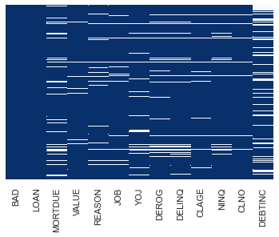

```python
# Heatmap for null/missing values
sns.heatmap(data.isnull(), cbar=False, yticklabels=False, cmap = 'Blues_r')
```

**Observations:**

- BAD and LOAN columns have no null values.
- There are missing values in all other columns.
- DEBTINC has most null values.
- Some rows seem to be missing more than 50% of values across columns.
- We will look more into the missing values and imputation of missing values in later steps.

### Summary Statistics

#### Summary Statistics - Numerical Variables

```python
# Check summary statistics for numerical variables

data.describe().T
```

|  | count | mean | std | min | 25% | 50% | 75% | max |
| --- | --- | --- | --- | --- | --- | --- | --- | --- |
| BAD | 5960.0 | 0.199497 | 0.399656 | 0.000000 | 0.000000 | 0.000000 | 0.000000 | 1.000000 |
| LOAN | 5960.0 | 18607.969799 | 11207.480417 | 1100.000000 | 11100.000000 | 16300.000000 | 23300.000000 | 89900.000000 |
| MORTDUE | 5442.0 | 73760.817200 | 44457.609458 | 2063.000000 | 46276.000000 | 65019.000000 | 91488.000000 | 399550.000000 |
| VALUE | 5848.0 | 101776.048741 | 57385.775334 | 8000.000000 | 66075.500000 | 89235.500000 | 119824.250000 | 855909.000000 |
| YOJ | 5445.0 | 8.922268 | 7.573982 | 0.000000 | 3.000000 | 7.000000 | 13.000000 | 41.000000 |
| DEROG | 5252.0 | 0.254570 | 0.846047 | 0.000000 | 0.000000 | 0.000000 | 0.000000 | 10.000000 |
| DELINQ | 5380.0 | 0.449442 | 1.127266 | 0.000000 | 0.000000 | 0.000000 | 0.000000 | 15.000000 |
| CLAGE | 5652.0 | 179.766275 | 85.810092 | 0.000000 | 115.116702 | 173.466667 | 231.562278 | 1168.233561 |
| NINQ | 5450.0 | 1.186055 | 1.728675 | 0.000000 | 0.000000 | 1.000000 | 2.000000 | 17.000000 |
| CLNO | 5738.0 | 21.296096 | 10.138933 | 0.000000 | 15.000000 | 20.000000 | 26.000000 | 71.000000 |
| DEBTINC | 4693.0 | 33.779915 | 8.601746 | 0.524499 | 29.140031 | 34.818262 | 39.003141 | 203.312149 |

**Observations:**

#### Summary Statistics - Categorical Variables

```python
# Check summary statistics for categorical variables

data.describe(include=['object']).T
```

|  | count | unique | top | freq |
| --- | --- | --- | --- | --- |
| REASON | 5708 | 2 | DebtCon | 3928 |
| JOB | 5681 | 6 | Other | 2388 |

**Observations:**

- Debt consolidation is more dominant reason for taking loan
- Job type Other is most frequent

Back to top

## Data Pre-processing and Feature Engineering:

```python
# Create a new dataframe df1 to work with from this step onwards
df1 = data.copy()
```

### Introducing feature: 'STATUS'

Since BAD is a binary target variable of numeric datatype, it is a good idea to add a categorical target variable encoding the two prediction classes as 'PAID' for 'Class 0' of BAD and 'DEFAULT' for 'Class 1' of BAD.

```python
df1.loc[data.BAD == 0, 'STATUS'] = 'PAID'
df1.loc[data.BAD == 1, 'STATUS'] = 'DEFAULTED'
```

### Drop rows with high percentage of missing features

Other than the target variable BAD or STATUS, the dataset has 12 feature columns. Let us see the rows with roughly more than 90% feature data missing, that is 11 or more columns:

```python
# Checking aggregated rows by STATUS with missing data in 11 or more columns

df1[df1.isnull().sum(axis=1)>=11].groupby('STATUS').count()
```

| STATUS | BAD | LOAN | MORTDUE | VALUE | REASON | JOB | YOJ | DEROG | DELINQ | CLAGE | NINQ | CLNO | DEBTINC |
| --- | --- | --- | --- | --- | --- | --- | --- | --- | --- | --- | --- | --- | --- |
| DEFAULTED | 1 | 1 | 0 | 0 | 0 | 0 | 0 | 0 | 0 | 0 | 0 | 0 | 0 |
| PAID | 1 | 1 | 0 | 0 | 0 | 0 | 0 | 0 | 0 | 0 | 0 | 0 | 0 |

```python
# Checking the actual rows with missing data in 10 or more columns
df1[df1.isnull().sum(axis=1)>=11]
```

|  | BAD | LOAN | MORTDUE | VALUE | REASON | JOB | YOJ | DEROG | DELINQ | CLAGE | NINQ | CLNO | DEBTINC | STATUS |
| --- | --- | --- | --- | --- | --- | --- | --- | --- | --- | --- | --- | --- | --- | --- |
| 3 | 1 | 1500 | NaN | NaN | NaN | NaN | NaN | NaN | NaN | NaN | NaN | NaN | NaN | DEFAULTED |
| 1405 | 0 | 10800 | NaN | NaN | NaN | NaN | NaN | NaN | NaN | NaN | NaN | NaN | NaN | PAID |

**Observation:** These 2 rows have no features data except for LOAN value, these can be dropped as they won't have any impact on feature analysis or classification model.

```python
# list indices for above rows and delete from main dataset, check shape of dataset after deletion

del_rows = df1[df1.isnull().sum(axis=1)>=11].index
df1.drop(del_rows, inplace=True)

df1.shape
```

```
(5958, 14)
```

Back to top

### Updating features: REASON and JOB

At this stage, it is important to deal with the missing values and outliers in the categorical variables, so it can help with better understanding of numerical variables with the categorical features.

**Encoding missing values in REASON and JOB with new label 'Unknown'**

```python
 # Filling missing values for REASON with 'Unknown'
df1['REASON'].fillna('Unknown', inplace=True)
# Filling missing values for JOB with 'Missing'
df1['JOB'].fillna('Unknown', inplace=True)
```

#### **Check for unique values in each column to help identify continuous categorical variables**

```python
# Checking unique values in each column
df1.nunique()
```

```
BAD           2
LOAN        540
MORTDUE    5053
VALUE      5381
REASON        3
JOB           7
YOJ          99
DEROG        11
DELINQ       14
CLAGE      5314
NINQ         16
CLNO         62
DEBTINC    4693
STATUS        2
dtype: int64
```

**Observations:**

```python
# read all columns in dataset df1
df1.columns
```

```
Index(['BAD', 'LOAN', 'MORTDUE', 'VALUE', 'REASON', 'JOB', 'YOJ', 'DEROG',
       'DELINQ', 'CLAGE', 'NINQ', 'CLNO', 'DEBTINC', 'STATUS'],
      dtype='object')
```

```python
# Create a list of numerical variables except target variable

num_cols = ['LOAN', 'MORTDUE', 'VALUE', 'DEBTINC', 'CLAGE', 'CLNO', 'YOJ']
```

```python
# Create a list of categorical variables - DEROG, DELINQ, NINQ are continuous categorical variables

cat_cols = ['REASON', 'JOB', 'DEROG', 'DELINQ', 'NINQ', 'STATUS']
```

```python
# Checking the percentage count of unique values in DEROG, DELINQ, NINQ

for i in cat_cols[2:5]:
    print('-'*40)
    print('Percent unique values in', i, 'are :')
    print(np.round(df1[i].value_counts(normalize=True)*100, 2))
    print('-'*40)
    print('*'*40)
```

```
----------------------------------------
Percent unique values in DEROG are :
0.0     86.20
1.0      8.28
2.0      3.05
3.0      1.10
4.0      0.44
6.0      0.29
5.0      0.29
7.0      0.15
8.0      0.11
9.0      0.06
10.0     0.04
Name: DEROG, dtype: float64
----------------------------------------
----------------------------------------
Percent unique values in DELINQ are :
0.0     77.68
1.0     12.16
2.0      4.65
3.0      2.40
4.0      1.45
5.0      0.71
6.0      0.50
7.0      0.24
8.0      0.09
11.0     0.04
10.0     0.04
15.0     0.02
12.0     0.02
13.0     0.02
Name: DELINQ, dtype: float64
----------------------------------------
----------------------------------------
Percent unique values in NINQ are :
0.0     46.44
1.0     24.57
2.0     14.31
3.0      7.19
4.0      2.86
5.0      1.38
6.0      1.03
7.0      0.81
10.0     0.51
8.0      0.40
9.0      0.20
11.0     0.18
12.0     0.04
13.0     0.04
17.0     0.02
14.0     0.02
Name: NINQ, dtype: float64
----------------------------------------
```

**Insights:**

- **DEROG:** About 86% have zero or missing derogatory reports; around 11% have 1 to 2, and around 3% have 3 or more derogatory reports.
- **DELINQ:** 77.7% have zero or missing deliquent credit lines; about 16.7% have 1 to 2, and around 5% have 3 or more deliquent credit lines.
- **NINQ:** 46.5% have zero or missing credit inquiries, ~ 38% have 1 to 2, and around 15% have 3 or more credit inquiries.

**Insight:** For DEROG, DELINQ and NINQ, replacing lower frequency sub-categories with the nearest highest value to improve visibility of percentage distribution of these variables.

### Updating features: DEROG, DELINQ and NINQ

**Replacing low frequency values in DEROG, DELINQ and NINQ**

```python
df1.loc[df1.DEROG>3, 'DEROG'] = 3
df1.loc[df1.DELINQ>3, 'DELINQ'] = 3
df1.loc[df1.NINQ>3, 'NINQ'] = 3
```

Back to top

```python
# Before proceeding with this step, let us make a copy of pre-processed dataframe to secure it for later analysis
df_before_imputation = df1.copy()
```

```python
# create new dataframe df_new by copying from df1 for data imputation
df_new = df1.copy()
```

```python
df_new.shape
```

```
(5958, 14)
```

### Treating Outliers

```python
def treat_outliers(df,col):
    Q1 = df[col].quantile(0.25) # 25th quantile
    Q3 = df[col].quantile(0.75)  # 75th quantile
    IQR = (Q3 - Q1)   # IQR Range
    Lower_Whisker = (Q1 - (1.5 * IQR))  #define lower whisker
    Upper_Whisker = (Q3 + (1.5 * IQR))  # define upper Whisker
    df[col] = np.clip(df[col], Lower_Whisker, Upper_Whisker) # all the values smaller than Lower_Whisker will be assigned value of Lower_Whisker
                                                            # and all the values above Upper_Whisker will be assigned value of Upper_Whisker
    return df

def treat_outliers_all(df, col_list):
    for c in col_list:
        df = treat_outliers(df,c)

    return df
```

**Treating Outliers for numerical variables:**

```python
num_cols = ['LOAN', 'MORTDUE', 'VALUE', 'YOJ', 'CLAGE', 'CLNO', 'DEBTINC']
df_new = treat_outliers_all(df_new, num_cols)
```

### Data Imputation - Replace Missing Values

```python
# Define function to Check the percentage of missing values in the each column
def percentage_missing_values(df):
    missing_values=pd.DataFrame(df.isnull().sum().rename_axis('Variables').reset_index(name='Missing Values'))
    missing_values["% Missing Values of all data"] = list(round((missing_values['Missing Values']/df.shape[0])*100,2))
    print('Percentage missing values per column of given dataset are:')
    return missing_values
```

```python
# Define function to replace missing values
def replace_missing_values(df):
    # Filling the missing values for DEROG with 0 for class 0 records, and with 1 for class 1 records
    df.loc[(df.BAD == 0) & (pd.isnull(df.DEROG) == True),'DEROG'] = 0
    df.loc[(df.BAD == 1) & (pd.isnull(df.DEROG) == True),'DEROG'] = 1

    # Filling the missing values for DELINQ with 0 for class 0 records, and with 1 for class 1 records
    df.loc[(df.BAD == 0) & (pd.isnull(df.DELINQ) == True),'DELINQ'] = 0
    df.loc[(df.BAD == 1) & (pd.isnull(df.DELINQ) == True),'DELINQ'] = 1

    # Filling the missing values for NINQ with median
    df['NINQ'].fillna(df['NINQ'].median(), inplace=True)

    # Filling missing values for DEBTINC with mean per class of target variable
    df.loc[(df.BAD == 0) & (pd.isnull(df.DEBTINC) == True),'DEBTINC'] = np.mean(df.loc[df.BAD == 0,'DEBTINC'])
    df.loc[(df.BAD == 1) & (pd.isnull(df.DEBTINC) == True),'DEBTINC'] = np.mean(df.loc[df.BAD == 1,'DEBTINC'])

    # Filling missing values for MORTDUE with mean per class of target variable
    df.loc[(df.BAD == 0) & (pd.isnull(df.MORTDUE) == True),'MORTDUE'] = np.mean(df.loc[df.BAD == 0,'MORTDUE'])
    df.loc[(df.BAD == 1) & (pd.isnull(df.MORTDUE) == True),'MORTDUE'] = np.mean(df.loc[df.BAD == 1,'MORTDUE'])

    # Filling remaining numerical cols with mean values
    for col in ['VALUE', 'YOJ', 'CLAGE', 'CLNO']:
        df[col] = df[col].fillna(df[col].mean())

    return df
```

#### **Checking for percentage of missing values per column**

```python
percentage_missing_values(df_new)
```

```
Percentage missing values per column of given dataset are:
```

|  | Variables | Missing Values | % Missing Values of all data |
| --- | --- | --- | --- |
| 0 | BAD | 0 | 0.00 |
| 1 | LOAN | 0 | 0.00 |
| 2 | MORTDUE | 516 | 8.66 |
| 3 | VALUE | 110 | 1.85 |
| 4 | REASON | 0 | 0.00 |
| 5 | JOB | 0 | 0.00 |
| 6 | YOJ | 513 | 8.61 |
| 7 | DEROG | 706 | 11.85 |
| 8 | DELINQ | 578 | 9.70 |
| 9 | CLAGE | 306 | 5.14 |
| 10 | NINQ | 508 | 8.53 |
| 11 | CLNO | 220 | 3.69 |
| 12 | DEBTINC | 1265 | 21.23 |
| 13 | STATUS | 0 | 0.00 |

#### Replacing Missing Values - after treating outliers

```python
# replace missing values in df_new
replace_missing_values(df_new)
```

|  | BAD | LOAN | MORTDUE | VALUE | REASON | JOB | YOJ | DEROG | DELINQ | CLAGE | NINQ | CLNO | DEBTINC | STATUS |
| --- | --- | --- | --- | --- | --- | --- | --- | --- | --- | --- | --- | --- | --- | --- |
| 0 | 1 | 1100 | 25860.0 | 39025.0 | HomeImp | Other | 10.5 | 0.0 | 0.0 | 94.366667 | 1.0 | 9.0 | 37.649155 | DEFAULTED |
| 1 | 1 | 1300 | 70053.0 | 68400.0 | HomeImp | Other | 7.0 | 0.0 | 2.0 | 121.833333 | 0.0 | 14.0 | 37.649155 | DEFAULTED |
| 2 | 1 | 1500 | 13500.0 | 16700.0 | HomeImp | Other | 4.0 | 0.0 | 0.0 | 149.466667 | 1.0 | 10.0 | 37.649155 | DEFAULTED |
| 4 | 0 | 1700 | 97800.0 | 112000.0 | HomeImp | Office | 3.0 | 0.0 | 0.0 | 93.333333 | 0.0 | 14.0 | 33.309298 | PAID |
| 5 | 1 | 1700 | 30548.0 | 40320.0 | HomeImp | Other | 9.0 | 0.0 | 0.0 | 101.466002 | 1.0 | 8.0 | 37.113614 | DEFAULTED |
| ... | ... | ... | ... | ... | ... | ... | ... | ... | ... | ... | ... | ... | ... | ... |
| 5955 | 0 | 41600 | 57264.0 | 90185.0 | DebtCon | Other | 16.0 | 0.0 | 0.0 | 221.808718 | 0.0 | 16.0 | 36.112347 | PAID |
| 5956 | 0 | 41600 | 54576.0 | 92937.0 | DebtCon | Other | 16.0 | 0.0 | 0.0 | 208.692070 | 0.0 | 15.0 | 35.859971 | PAID |
| 5957 | 0 | 41600 | 54045.0 | 92924.0 | DebtCon | Other | 15.0 | 0.0 | 0.0 | 212.279697 | 0.0 | 15.0 | 35.556590 | PAID |
| 5958 | 0 | 41600 | 50370.0 | 91861.0 | DebtCon | Other | 14.0 | 0.0 | 0.0 | 213.892709 | 0.0 | 16.0 | 34.340882 | PAID |
| 5959 | 0 | 41600 | 48811.0 | 88934.0 | DebtCon | Other | 15.0 | 0.0 | 0.0 | 219.601002 | 0.0 | 16.0 | 34.571519 | PAID |

5958 rows × 14 columns

**Check for missing values in dataset**

```python
# Checking missing values using pre-defined function
percentage_missing_values(df_new)
```

```
Percentage missing values per column of given dataset are:
```

|  | Variables | Missing Values | % Missing Values of all data |
| --- | --- | --- | --- |
| 0 | BAD | 0 | 0.0 |
| 1 | LOAN | 0 | 0.0 |
| 2 | MORTDUE | 0 | 0.0 |
| 3 | VALUE | 0 | 0.0 |
| 4 | REASON | 0 | 0.0 |
| 5 | JOB | 0 | 0.0 |
| 6 | YOJ | 0 | 0.0 |
| 7 | DEROG | 0 | 0.0 |
| 8 | DELINQ | 0 | 0.0 |
| 9 | CLAGE | 0 | 0.0 |
| 10 | NINQ | 0 | 0.0 |
| 11 | CLNO | 0 | 0.0 |
| 12 | DEBTINC | 0 | 0.0 |
| 13 | STATUS | 0 | 0.0 |

Back to top

## Exploratory Data Analysis

### Univariate Analysis:

Priliminary analysis of individual variables was observed in the Summary Statistics and Data pre-processing sections.

In this section, we visualize each variable individually.

- For numerical variables, we use histograms and box plots to understand the distribution and outliers for each variable.
- For catergorical variables, we use bar graphs with percentage distribution of unique values in each category to get deeper insights into each variable.

#### Target variable 'BAD'

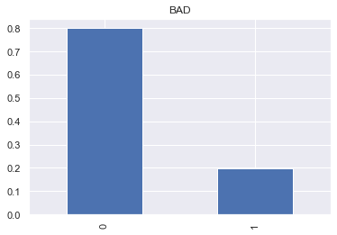

```python
# Visualizing the target variable 'BAD'

df_new['BAD'].value_counts(normalize=True).plot.bar(title='BAD')
```

**Observation:** As we can see 80% of loans are class 0 (non-defaulters or paid), and 20% are class 1 (defaulted).

#### Univariate Analysis - Numerical Variables

```
LOAN
Skew : 0.83
```

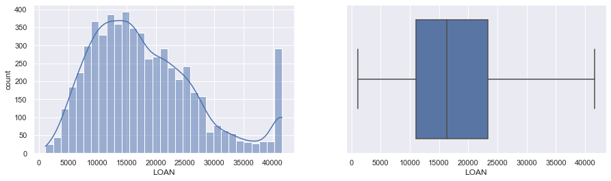

```
MORTDUE
Skew : 0.69
```

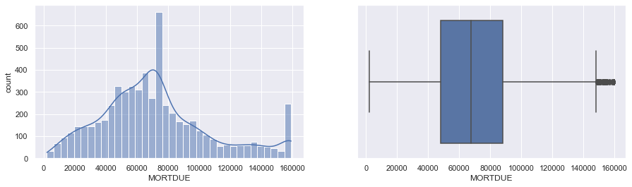

```
VALUE
Skew : 0.78
```

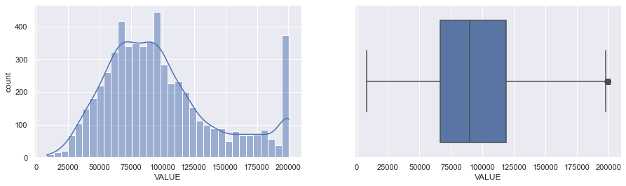

```
YOJ
Skew : 0.93
```

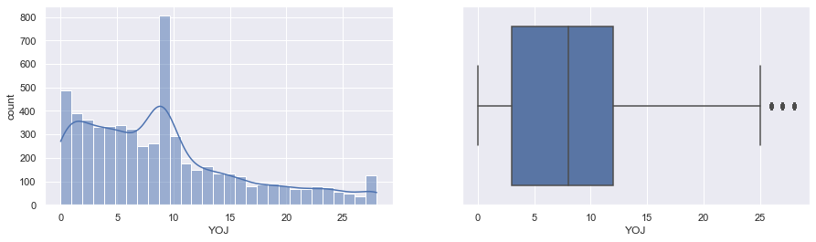

```
CLAGE
Skew : 0.5
```

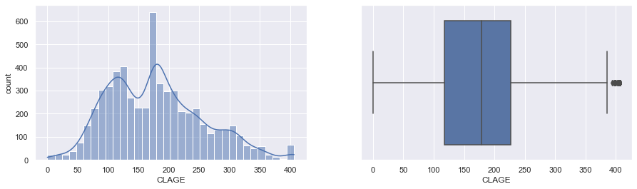

```
CLNO
Skew : 0.37
```

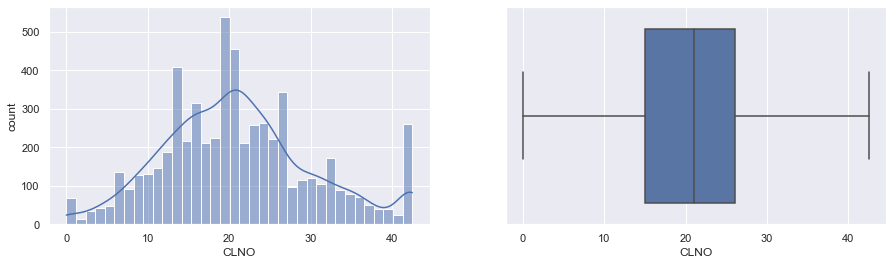

```
DEBTINC
Skew : -0.69
```

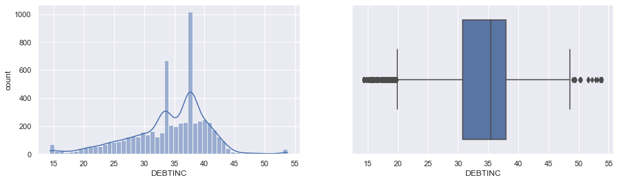

```python
for col in num_cols:
    print(col)
    print('Skew :',round(df_new[col].skew(),2))
    plt.figure(figsize=(15,4))
    plt.subplot(1,2,1)
    sns.histplot(data=df_new, x=col, kde = True)
    #df2[col].hist(bins = 20, grid = False)
    plt.ylabel('count')
    plt.subplot(1,2,2)
    sns.boxplot(x=df_new[col])
    plt.show()
```

**Insights about numerical variables:**

- The skewness of variables has improved and we can see fairly normal distribution for all variables, as can be seen from the box plots above.
- MORTDUE, DEBTINC, CLAGE, CLNO have high modality at median, as was anticipated earlier.
- Higher concentration towards peripheral values can be seen for LOAN, MORTDUE, CLNO, YOJ, and DEBTINC, as was anticipated at the step of treating outliers.
- YOJ and LOAN are still slightly right skewed.

#### Univariate Analysis - Categorical Variables

```python
# Function to create barplots that indicate percentage for each sub-category
def perc_on_bar(plot, feature):
    total = len(feature) # length of the column
    for p in ax.patches:
        percentage = '{:.2f}%'.format(100 * p.get_height()/total) # percentage of each class of the category
        x = p.get_x() + p.get_width() / 2 - 0.05 # width of the plot
        y = p.get_y() + p.get_height()           # height of the plot
        ax.annotate(percentage, (x, y), size = 12) # annotate the percentage

    plt.show() # show the plot
```

```
Percent unique values in REASON are :
```

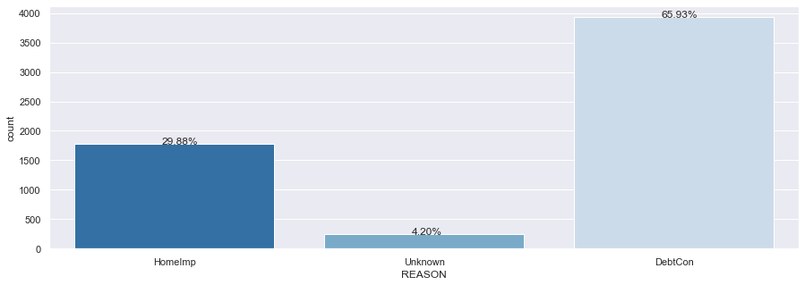

```
Percent unique values in JOB are :
```

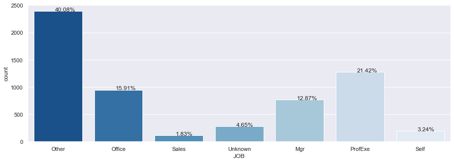

```
Percent unique values in DEROG are :
```

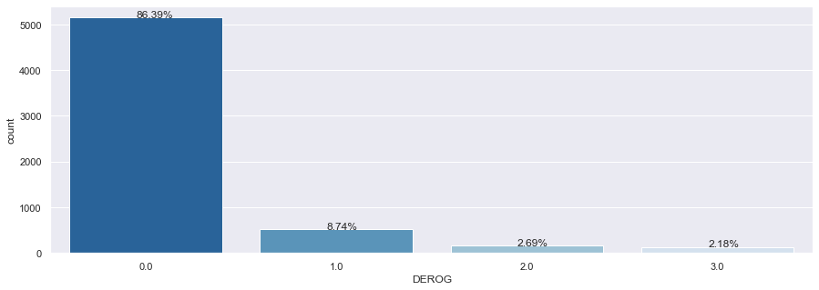

```
Percent unique values in DELINQ are :
```

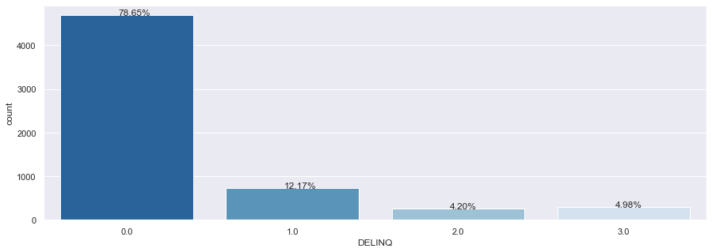

```
Percent unique values in NINQ are :
```

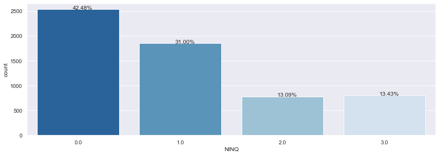

```python
# Visualizing distribution for REASON, JOB, DEROG, DELINQ, NINQ
for col in cat_cols[:-1]:
    print('Percent unique values in', col, 'are :')
    plt.figure(figsize=(15,5))
    ax = sns.countplot(df_new[col], palette = 'Blues_r')
    perc_on_bar(ax,df_new[col])
```

**Insights about categorical variables:**

Back to top

### Hypothesis Verification:

Here, we can check our initial hypothesis using a simple crosstab of all numerical features against the target feature 'STATUS' as follows:

```python
round(df_new.groupby(['STATUS']).mean(),2)
```

| STATUS | BAD | LOAN | MORTDUE | VALUE | YOJ | DEROG | DELINQ | CLAGE | NINQ | CLNO | DEBTINC |
| --- | --- | --- | --- | --- | --- | --- | --- | --- | --- | --- | --- |
| DEFAULTED | 1.0 | 16488.72 | 66906.04 | 92817.21 | 8.01 | 0.60 | 0.94 | 150.70 | 1.30 | 20.77 | 37.65 |
| PAID | 0.0 | 18446.21 | 72723.89 | 99962.87 | 9.09 | 0.11 | 0.21 | 185.59 | 0.89 | 21.10 | 33.31 |

**Insights based on mean values of features per class of STATUS:**

- Higher values of LOAN, MORTDUE, VALUE, YOJ, and CLAGE are associated with PAID status of loan (class 0)
- Higher values of DEROG, DELINQ, NINQ and DEBTINC are associated with DEFAULTED Status of loan (Class 1)
- As we can see, DEROG, DELINQ and NINQ are the biggest differentiators of the binary classes. Loan applicants with higher value of derogatory reports, higher number of delinquint credit lines or higher number of credit inquiries are more likely to DEFAULT on the loan
- Also, average DEBTINC is more for class 1, which implies that loan applicants with higher debt to income ratio are more likely to DEFAULT on the loan
- Loan applicants with lesser years in job (lower average of YOJ) are more likely DEFAULT on the loan
- LOAN, MORTDUE, VALUE, CLAGE and CLNO averages for class 1 are smaller than that for class 0, but the difference between the averages across the two classes is not very high, while considering the imbalanced distribution of classes (80-20 for class 0 and class 1), it cannot be determined if these variables have predictive power.

**Thus, the hypotheses can be futher verified as -**

- It appears that loan applicants with high DEBTINC (debt to income ratio), lower YOJ (years in current job), lower value of oldest credit line, and poor credit history (that is higher number of DEROG, DELINQ, NINQ) are more likely to default on the loan.
- Number of credit line (CLNO) cannot be determined as a predictor of classes at this point.
- The avergae LOAN, MORTDUE, VALUE are slightly lower for class 1, but cannot be determined as predictor variables at this point.

Back to top

### Bivariate Analysis:

In this section, we explore the relationship of each variable to the target variable.

- For numerical variables, we use simple crosstab, followed by histogram distribution overlayed with box plots per class of the target variable to understand relation of each variable to each class of the target variable
- For catergorical variables, we use barplots divided into two classes of target variable per sub-category to see the influence of each of it over the target variable.

#### Bivariate Analysis - Numeric Variables

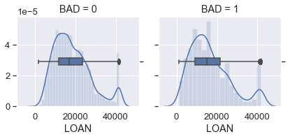

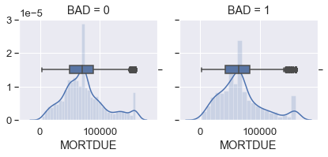

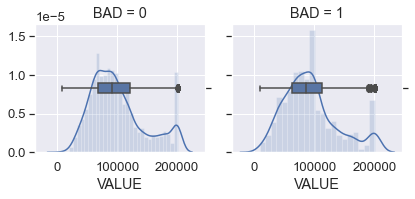

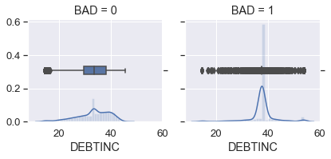

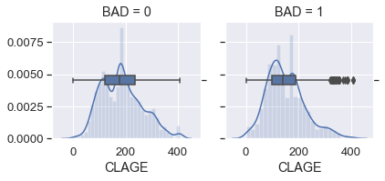

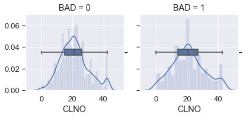

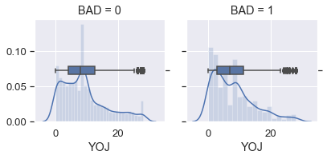

```python
# Visualize distribution of variables LOAN, MORTDUE, VALUE, YOJ compared to BAD

sns.set(font_scale=1.2)

def dist_boxplot(x, **kwargs):
    ax = sns.distplot(x, hist_kws=dict(alpha=0.2))
    ax2 = ax.twinx()
    sns.boxplot(x=x, ax=ax2)
    ax2.set(ylim=(-5, 5))

g = sns.FacetGrid(df_new, col="BAD")
G1 = g.map(dist_boxplot, 'LOAN', data = df_new)

g = sns.FacetGrid(df_new, col="BAD")
G2 = g.map(dist_boxplot, 'MORTDUE', data = df_new)

g = sns.FacetGrid(df_new, col="BAD")
G3 = g.map(dist_boxplot, 'VALUE', data = df_new)

g = sns.FacetGrid(df_new, col="BAD")
G4 = g.map(dist_boxplot, 'DEBTINC', data = df_new)

g = sns.FacetGrid(df_new, col="BAD")
G5 = g.map(dist_boxplot, 'CLAGE', data = df_new)

g = sns.FacetGrid(df_new, col="BAD")
G6 = g.map(dist_boxplot, 'CLNO', data = df_new)

g = sns.FacetGrid(df_new, col="BAD")
G7 = g.map(dist_boxplot, 'YOJ', data = df_new)
```

**Insights about bivariate analysis of numerical variables:**

#### Bivariate Analysis - Categorical Variables

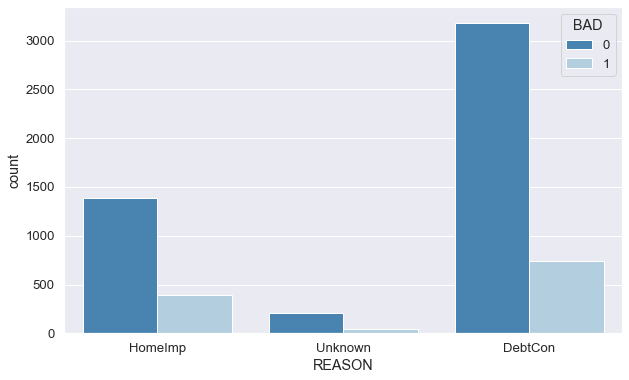

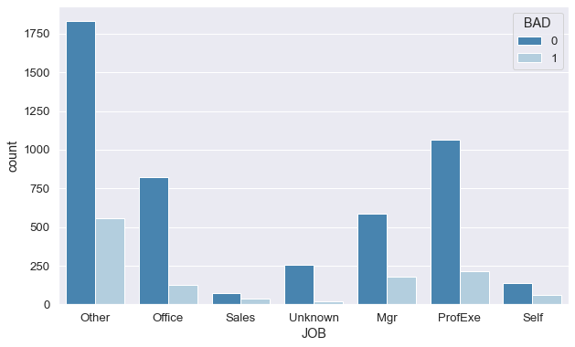

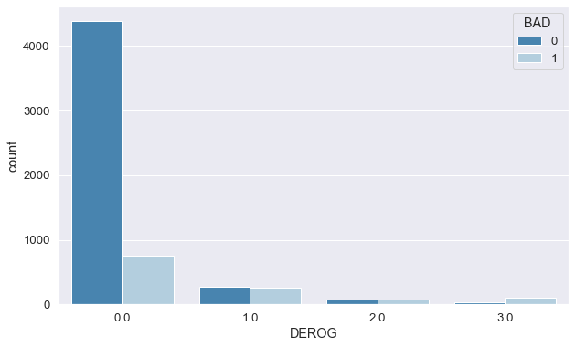

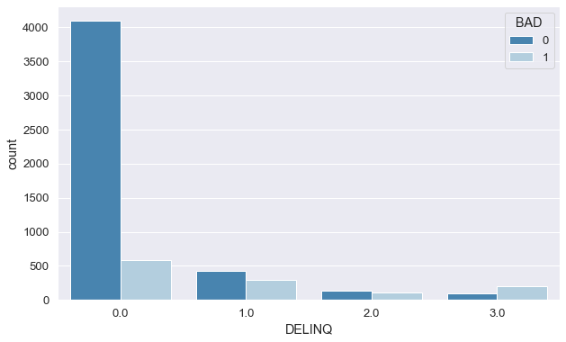

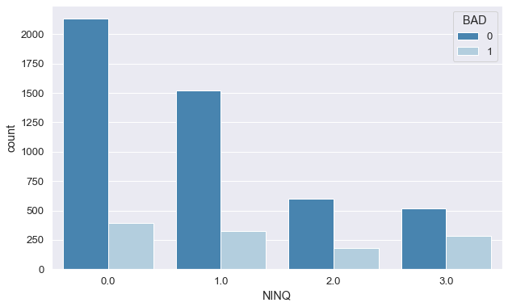

```python
for i in cat_cols[:-1]:
    plt.figure(figsize=(10, 6))
    sns.countplot(x = df_new[i] , hue='BAD', data=df_new, palette='Blues_r')
    plt.show()
```

**Insights about bivariate analysis of BAD vs. Categorical variables:**

- **REASON:** Most loans are taken for Debt Consolidation rather than home improvement. The percentage distribution over two classes of target variable is similar for both values of REASON with nearly 80% for class 0 and 20% for class 1.
- **JOB:** Most loan applications are for JOB type Other. This variable shows a good differential distribution of the two classes. Office worker and Professional Executive are most likely to pay their loans, while Sales and Self-employed are more likely to default. Thus, JOB seems to have a good predictor ability and could prove to be an important feature in our classification model.
- **DEROG, DELINQ** and **NINQ:** These 3 variables show the credit history of the loan applicant, and their distribution is indicative of more probability to default a loan as the credit history grows poorer, that is higher values of each of these variables.

Back to top

### Multivariate Analysis

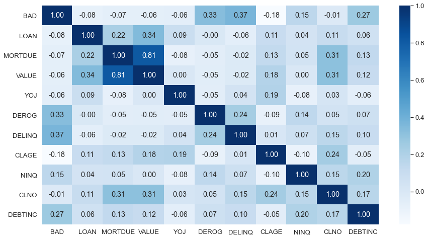

```python
#plotting the correlation matrix after data processing
plt.figure(figsize=(15,8))
sns.heatmap(df_new.corr(),annot=True, fmt='0.2f', cmap='Blues')
```

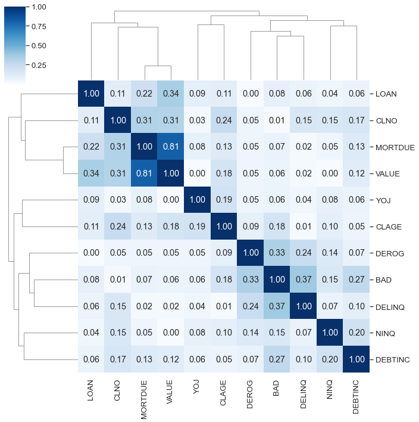

```python
# Clustermap for understanding correlation of numerical variables

sns.clustermap(df_new.corr().abs(),annot=True, fmt = ".2f", cmap = 'Blues')
```

**Insights about data using multivariate analysis:**

Back to top

## Design Approach

In Exploratory Data Analysis and pre-processing steps, we obtained good insights into the data and understood the correlation of independent features and their discrimination power to identify whether a loan applicant is more likely to DEFAULT or Not.

In next steps, we will build and analyze classifier models to predict whether a loan is most likely to DEFAULT or be PAID, if the loan applicant was approved.

Since this is a Binary Classification problem, with imbalanced data, our focus will be on following techniques:

- Data preparation techniques:
  - Separate Independent and Dependent variables
  - Split data into training and test sets using stratification on target variable
  - Check for multicollinearity
  - Treat data for imbalance using SMOTE technique for Logistic regression model
- Classification techniques:
  1. Logistic Regression - baseline, optimized, resampled data
  2. Decision Tree - baseline, tuned
  3. Random Forest - baseline, tuned
- Model Analysis techniques:
  - Confusion Matrix
  - Classification Report
  - Feature importances

## Model Evaluation Criterion

Let us begin with defining the performance evaluation function as follow:

```python
# Creating metric function
def metrics_score(model, data, actual, predicted):
    print(model, data, 'set metrics')
    print(classification_report(actual, predicted))
    cm = confusion_matrix(actual, predicted)
    plt.figure(figsize=(8,5))
    sns.heatmap(cm, cmap='Blues', annot=True,  fmt='.2f', xticklabels=['Good', 'Bad'], yticklabels=['Paid', 'Defaulted'])
    plt.title(str(model)+' '+str(data)+' set confusion matrix')
    plt.xlabel('Predicted')
    plt.ylabel('Actual')
    plt.show()
```

Back to top

### Data Preparation for Logistic Regression model

We will start with using the pre-processed dataset "df_new".

```python
# Before proceeding with this step, let us make a copy of df_new in case needed later
df_imputed_data = df_new.copy()
```

```python
df_new.BAD.value_counts(normalize=True)
```

```
0    0.800604
1    0.199396
Name: BAD, dtype: float64
```

### **Separating the target variable from other variables**

```python
# Drop the dependent variable from the dataframe and create the X(independent variable) matrix

X = df_new.drop(columns = ['BAD', 'STATUS'])
```

```python
# Create y(dependent varibale)

y = df_new['BAD']
```

```python
# Create dummy variables for the categorical variables - Hint: use the get_dummies() function

X = pd.get_dummies(X, drop_first=True)
```

```python
X.columns
```

```
Index(['LOAN', 'MORTDUE', 'VALUE', 'YOJ', 'DEROG', 'DELINQ', 'CLAGE', 'NINQ',
       'CLNO', 'DEBTINC', 'REASON_HomeImp', 'REASON_Unknown', 'JOB_Office',
       'JOB_Other', 'JOB_ProfExe', 'JOB_Sales', 'JOB_Self', 'JOB_Unknown'],
      dtype='object')
```

```python
print(X.shape, y.shape)
```

```
(5958, 18) (5958,)
```

Back to top

### Check for Multicollinearity

Let us use the Variance Inflation Factor (VIF), to check if there is multicollinearity in the data.

Features having a VIF score > 5 will be dropped/treated till all the features have a VIF score < 5

```python
# make copy of X to check for multicollinearity
X1 = X.copy()
y1 = y.copy()

print(X1.shape, y1.shape)
```

```
(5958, 18) (5958,)
```

```python
# add the intercept term for checking variance inflation factor
X1 = sm.add_constant(X1)
```

```python
# Split the data into training and test set with a split of 70:30

X_train1, X_test1, y_train1, y_test1 = train_test_split(X1, y1, test_size=0.30 , stratify=y, random_state=42)
```

```python
from statsmodels.stats.outliers_influence import variance_inflation_factor

# function to check VIF
def checking_vif(train):
    vif = pd.DataFrame()
    vif["feature"] = train.columns

    # calculating VIF for each feature
    vif["VIF"] = [
        variance_inflation_factor(train.values, i) for i in range(len(train.columns))
    ]
    return vif


print(checking_vif(X_train1))
```

```
           feature        VIF
0            const  52.075681
1             LOAN   1.260585
2          MORTDUE   3.145839
3            VALUE   3.463009
4              YOJ   1.093033
5            DEROG   1.099569
6           DELINQ   1.109343
7            CLAGE   1.168091
8             NINQ   1.125443
9             CLNO   1.315439
10         DEBTINC   1.150471
11  REASON_HomeImp   1.138623
12  REASON_Unknown   1.159244
13      JOB_Office   1.893548
14       JOB_Other   2.539468
15     JOB_ProfExe   2.162477
16       JOB_Sales   1.141350
17        JOB_Self   1.271677
18     JOB_Unknown   1.455155
```

**Insights about Multicollinearity check using VIF Score:**

- The VIF is less than 5 for all the independent variables, so we can continue with Logistic Regression Model without dropping any columns.

Back to top

#### Splitting the data into 70% train and 30% test set

Note: Use of stratify parameter in train_test_split makes a split so that the proportion of values in the sample produced will be the same as the proportion of values provided to parameter stratify.

So, in our case, since the variable y is a binary categorical variable with values 0 and 1 and there are 80% of zeros and 20% of ones, stratify=y will make sure that the random split has 80% of 0s and 20% of 1s.

```python
# Split the data into training and test set with a split of 70:30 and stratify=y

X_train, X_test, y_train, y_test = train_test_split(X, y, test_size=0.30, stratify=y, random_state=42)
```

```python
print(X_train.shape, X_test.shape, y_train.shape, y_test.shape)
```

```
(4170, 18) (1788, 18) (4170,) (1788,)
```